# Akutt bukkirurgioperasjoner før/etter utvidelse av aktuttstuetilbud

Lena

## Sammendrag

Heile oppgåva/kvalitetssikringsprosjektet dreiar seg om (eksklusjon allereie gjort) å samanlikne to toårs-kohortar av akuttinngrep på gastro(mage-tarm)-seksjonen på Haukeland Sjå vedlagde protokoll, som vi ikkje kjem til å fylgje opp 100%. Det er noko vil ikkje kjem til å sjå på. Alle samanlikningar der det ikkje er fullstendige data, skal gjerast med utgangspunkt i dei data vi har (n vil altså varierer etter kva vi ser på). Vedlagt er også eit (uferdig) xl-ark der studentane har undersøkt og funne fram til tal/% i xl-filene – der ser du grovt sett kva data vi samanliknar og vil har statistiske opplysningar om. Målet er ein artikkel i tidsskriftet BMJ Quality & Safety.

Gastrokirurgiske pasientar, toårs-kohortar: 1. Dei som gjennomgjekk akutt bukkirurgi i tidsrommet 01.01.2018-31.12.2019 2. Dei som gjennomgjekk akutt bukkirurgi i tidsrommet 01.04.2020-31.03.2022 Hovudpoenget er at det fram til februar 2020 var avgrensa tilgang til “akuttstove” på dagtid, dvs. at det var avsett eit eige team til å ta seg av akuttoperasjonar på dagtid berre kring 2 dagar/veke. Frå februar 2020 vart dette tilbodet utvida til fem dagar/veke (måndag til fredag).

*Kohort 1 2028-2019*: - inngrep/pasientar før tilgang på ei ekstra akuttstove på dagtid som rutine på måndag-fredager - totalt 1199 inngrep, og 959 pasientar

*Kohort 2, 1.4.2020-31.03.2022* - inngrep etter slik tilgang var etablert. - 1292 inngrep og 1002 pasientar.

- Ei fil på pasientnivå - kun siste inngrep
- Ei fil med alle inngrep

```
## [1] "GrupperingsAar" "PrioritetGML"
```

Vi ynskjer å sjå om vi finn att effekt av denne endringa, og undersøkjer ein del variablar som har med logistikk å gjere, eks: - om fraksjonen av operasjonar på dagtid vs. på vakttid er blitt endra, - om fleire pasientar vert opererte innan den tidsfristen kirurgen ynskjer seg - … og også nokre variablar som har med utfall å gjere: - operajonstid, - overleving 7, 30 og 365 dagar, - grad av blødning, - førekomst av reoperasjonar innan 7 døger

I tillegg må vi samanlikne kohortane for ein del basalkarakteristika: kjønn, alder, “funksjonsklasse” gradert som ASA.

## Her er det vi gjerne vil ha statistisk hjelp til.

### Deskriptiv statistikk av pasient-populasjonene

Ønsker først å gjere ei case-mix-samanlikning av pasientane, (dvs. dei 959 mot dei 1002) der vi ser på:

**Alder**

Fordeling Aldersgrupper: 18-39, 40-49, 50-59, 60-69, 70-79 og 80+, sammenligne fordeling.

|  | Gr1 | Gr2 | PstGr1 | PstGr2 |
| --- | --- | --- | --- | --- |
| 18-39 | 195 | 186 | 20.30000 | 18.6000 |
| 40-49 | 108 | 110 | 11.30000 | 11.0000 |
| 50-59 | 146 | 142 | 15.20000 | 14.2000 |
| 60-69 | 178 | 175 | 18.60000 | 17.5000 |
| 70-79 | 186 | 217 | 19.40000 | 21.7000 |
| 80+ | 146 | 172 | 15.20000 | 17.2000 |
| Menn | 509 | 500 | 53.07612 | 49.9002 |

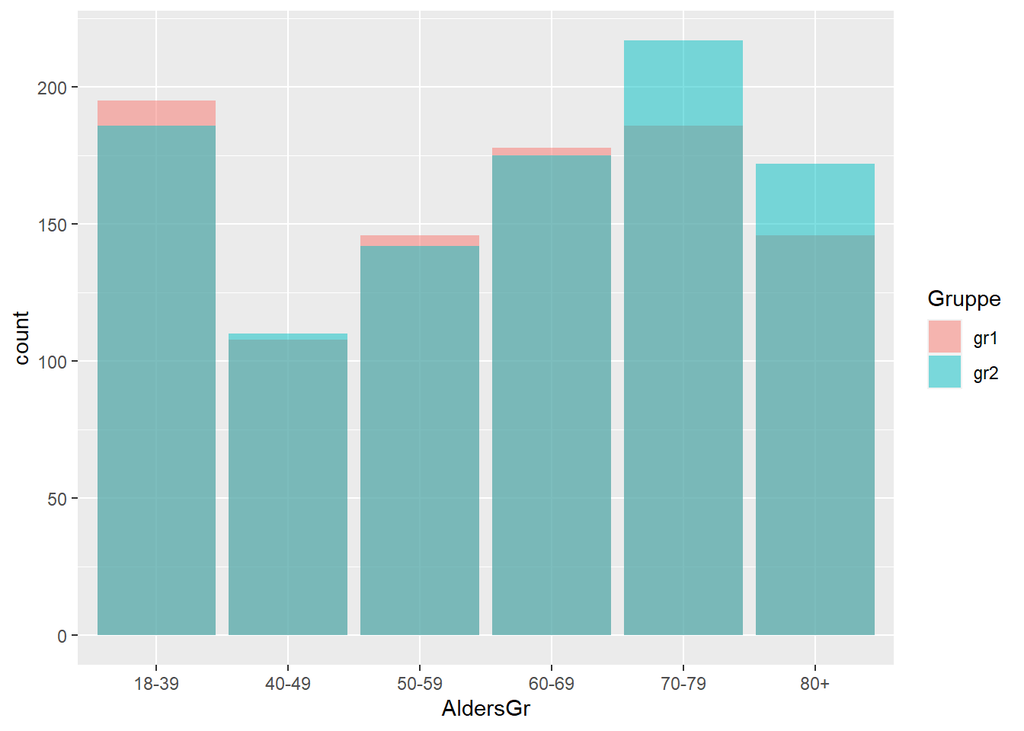

**ASA-klassefordeling**

|  | gr1 | gr2 |
| --- | --- | --- |
| ASA-klasse 1 Frisk pasient | 11.1 | 10.2 |
| ASA-klasse 2 Pasient med lettere grad av systemsykdom | 34.6 | 37.9 |
| ASA-klasse 3 Pasient med alvorlig, begrensende grad av systemsykdom | 41.1 | 37.6 |
| ASA-klasse 4 Pasient med livstruende alvorlighetsgrad av systemsykdom | 10.9 | 11.5 |
| ASA-klasse 5 Moribund pasient | 0.1 | 0.4 |
| NULL | 2.2 | 2.4 |

*Det er blittelitt høyere andel av ASA 4 (og 5, få obs.) etter endring, men det er også bittelitt høyere andel av ASA 1+2.*

## Resultater

**Mors (døde)**

- *Mors* fortel om pasienten er registrert som død (=1) då vi gjorde datauttrekka.
- *mors_7* har eit 1-tal om dødsfallet skjedde < 7 døger etter siste inngrep,
- *mors_30* < 30 døger etter siste inngrep og kolonne BE i løpet av eitt år/365 dagar etter siste inngrep.
- Kan du også sjekke om det er skilnad i mortalitet etter 7, 30 og 365 dagar i dei to kohortane når det gjeld aldersgruppene? Her er vi ute etter om særleg dei eldre og presumptivt mekir skrøpelege har fått endra overleving etter innføring av akuttstove (det ser førebels ut for oss som at totalmortaliteten og også ASA-skåre har auka frå kohort 1 til 2.

Andel (%) døde etter 7, 30 og 365 dager i ulike aldersgrupper.

|  | gr1 | gr1 | gr1 | gr2 | gr2 | gr2 |
| --- | --- | --- | --- | --- | --- | --- |
| 18-39 | 0.0 | 0.5 | 1.5 | 1.1 | 1.1 | 2.7 |
| 40-49 | 0.9 | 0.9 | 3.7 | 2.7 | 2.7 | 6.4 |
| 50-59 | 0.7 | 0.7 | 9.6 | 0.7 | 4.2 | 15.5 |
| 60-69 | 2.2 | 6.2 | 19.7 | 5.1 | 7.4 | 18.3 |
| 70-79 | 3.8 | 10.2 | 25.3 | 3.2 | 11.5 | 24.4 |
| 80+ | 9.6 | 16.4 | 36.3 | 9.3 | 16.3 | 34.9 |
| Totalt | 2.8 | 5.9 | 16.3 | 3.8 | 7.7 | 17.9 |

## Overlevelsesanalyser

Vi mangler total eksponeringstid i studien for pasienter som har overlevd. Det blir derfor vanskelig å gjøre overlevelsesanalyser.

Så ynskjer vi å samanlikna inngrepa dei to kohortane av inngrep:

- **Prioritet** = Fordelinga i hastegrader (dvs. kor raskt kirurgen har ynskt inngrepet gjort etter at det er meldt inn).

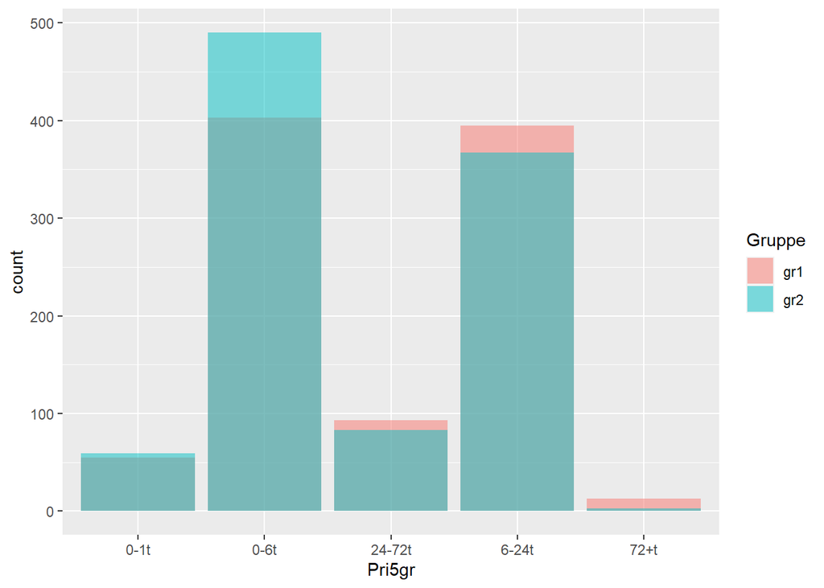

Opr innan prio: Så ynsker vi å sjå om det er skilnader mellom kohort 1 og 2 når det gjeld dei ulike prioriteringskategoriane, dvs. mellom dei som er ynskt opererte innan 1t, 6 t, 24 t, 72 t og over 72t. *Men det er vel det samme som ønsket over? Eller tenker du på om det er forskjell mellom pasientene som ble tilfeller er valgt inn i de ulike prioriteringsgruppene før og etter “reformasjonen”?*

#### Satt hastegrad

```r
Pas$Prioritet <- factor(Pas$Prioritet, levels= c('0-6t', '6-24t', '24-72t', '72+t'))

tabPri <- round(prop.table(table(Pas[ ,c('Gruppe', 'Prioritet' )]), 1)*100, 1)
```

- **Opr innan prio** Eit 1-tal her tyder at inngrepet er starta innan den tidsfristen kirurgen ynskte. Vi ynskjer å samanlikne om det totalt sett er skilnad i graden av oppfylling av tidsfristar, dvs. fraksjonen av inngrep (med talet 1 i kolonne I) mellom dei to kohortane.

```
##               Gruppe
## Opr_innan_prio       gr1       gr2
##              0 0.3149114 0.3043912
##              1 0.6850886 0.6956088
```

```
##
##  2-sample test for equality of proportions without continuity correction
##
## data:  tapply(Pas$Opr_innan_prio, Pas$Gruppe, sum) out of table(Pas$Gruppe)
## X-squared = 0.25375, df = 1, p-value = 0.6144
## alternative hypothesis: two.sided
## 95 percent confidence interval:
##  -0.05145855  0.03041826
## sample estimates:
##    prop 1    prop 2
## 0.6850886 0.6956088
```

Ca 1%-poeng flere opereres innen fristen. Ikke signifikant.

#### **Knivtid** (den tida kirurgen brukte på inngrepet i minuttar). Vi ynskjer å samanlikne gjennomsnitta og medianar i kohort 1 og kohort 2 her

- Før: Median: 76 Gjennomsnitt: 87, interkvartil: 35 - 123
- Etter: Median: 82 Gjennomsnitt: 95, interkvartil: 41 - 133
- p-verdi for forskjell mellom gjennomsnittlig knivtid: 0.0098
- p-verdi for forskjell mellom median knivtid: 0.0189

#### **Blødning** i ml

– kor mykje blødning som er registrert i løpet av inngrepet. Dette er skeivfordelte data, så er det best å samanlikne median/interkvartilar?

- Før: Median: 50 Gjennomsnitt: 126.6, interkvartil: 5 - 100
- Etter: Median: 40 Gjennomsnitt: 143.7, interkvartil: 5 - 100
- p-verdi for forskjell mellom gjennomsnittlig blødning: 0.5389
- p-verdi for forskjell mellom median blødning: 0.96

#### **Andel akuttinngrep på dagtid**

Oppstart på dagtid har eit 1-tal i variabelen «Dagtid». Det skal då vere 0 i “helg-helgedag”, dvs. laurdag/sundag og bevegelege heilagdagar). Kolonne «Kveld» kan vere 1 samstundes som det er 1 i kolonne «Dagtid» - då er det eit inngrep som strekkjer seg over både dag og kveld/natt.  
Dersom det er 1 i kolonne «Kveld» utan at det er 1 i «Dagtid», er inngrepet starta på vakttid og ikkje dagtid. *Ut fra dette forstår jeg at man bare trenger å se på variabelen Dagtid når man ser på operasjoner gjort på dagtid*

Kor stor andel av desse akuttinngrepa på ble utført på: - kvardagsdøger måndag-fredag (akuttstove tilgjengeleg kvar dag for kohort 2, og meir sporadisk for kohort 1) 26.9, 24.8, 73.1, 75.2

**Totaltid**

- Før: Median: 190 Gjennomsnitt: 198.8, interkvartil: 134 - 253
- Etter: Median: 199 Gjennomsnitt: 208.3, interkvartil: 138 - 265
- p-verdi for forskjell mellom gjennomsnittlig totaltid: 0.0195
- p-verdi for forskjell mellom median totaltid: 0.0523
- **Liggjetid på sjukehus** = totalt tal på døger innlagt. Dette er også ein skeivfordelt variabel som vi gjerne vil samanlikne mellom dei to kohortane. Variabel: *Liggedager*
- Før: Median: 9 Gjennomsnitt: 14.8, interkvartil: 4 - 17
- Etter: Median: 8 Gjennomsnitt: 13.3, interkvartil: 4 - 16
- p-verdi for forskjell mellom gjennomsnittlig liggetid: 0.0693
- p-verdi for forskjell mellom median liggetid: 0.1752

#### Inngrep/pasienter, reoperasjoner

Prosent reoperasjoner <= 7 dager: Før: 1.4, Etter: 0.1 Antall reoperasjoner totalt: Før: 3.4, Etter: 0.2